# GAMLSS modelling in mgcv and mgcViz

Matteo Fasiolo

September 20 2019

N.B. GAMLSS models cannot be fitted using `bam` or `bamV`. Big Data methods for GAMLSS models in `mgcv` are still under development.

# Grip strength modelling

We consider a simple data set containing data on grip strength (HG) vs age:

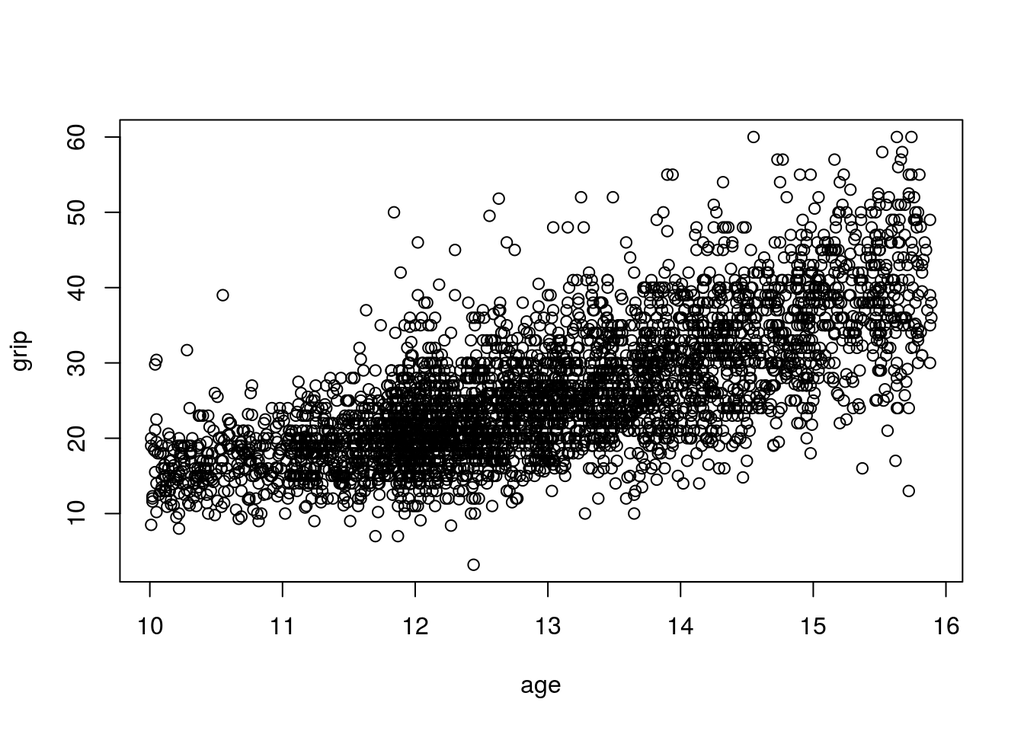

```r
library(gamlss.data)
data(grip)

plot(grip ~ age, data = grip)
```

We fit a standard Gaussian GAM

```r
library(mgcViz)
fit1 <- gamV(grip ~ s(age),
             data = grip,
             aViz = list(nsim = 50))
```

Then we check the residuals mean of a grid of values along `age`:

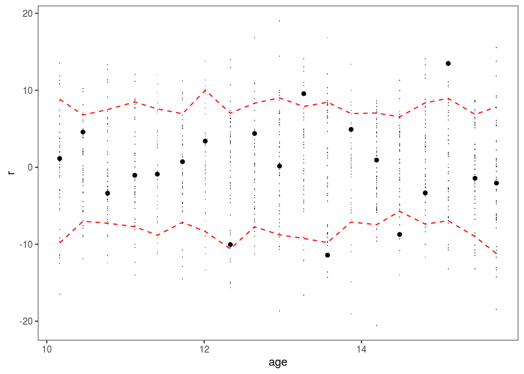

```r
check1D(fit1, "age") + l_gridCheck1D()
```

Now we check the residuals standard deviation along `age`

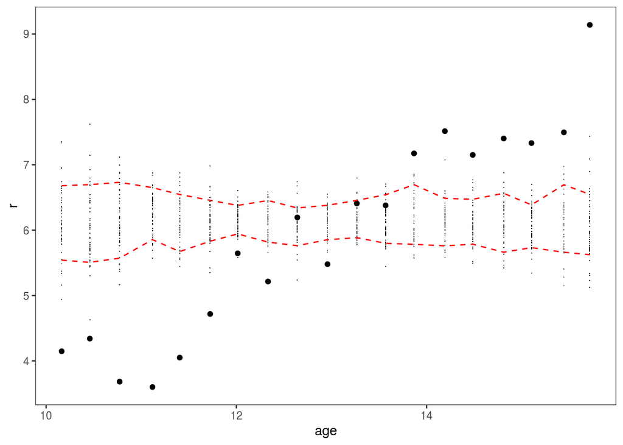

```r
check1D(fit1, "age") + l_gridCheck1D( sd ) # <- notice that we are looking at stan dev
```

The variance is clearly increasing with `age`. We take this into account using a `gaulss` model

```r
fit2 <- gamV(list(grip ~ s(age), ~ s(age)),
             data = grip,
             family = gaulss,
             aViz = list(nsim = 50))
```

and we repeat the check

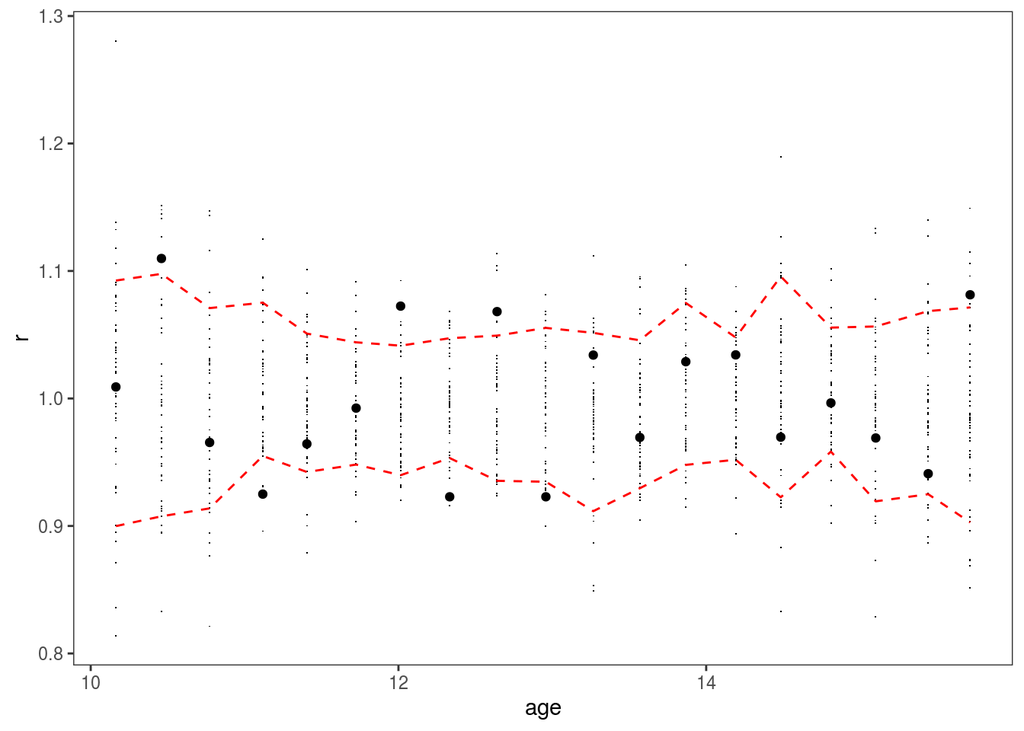

```r
check1D(fit2, "age") + l_gridCheck1D( sd )
```

The residual check now looks ok. These are the estimated mean and log stand. dev. effects

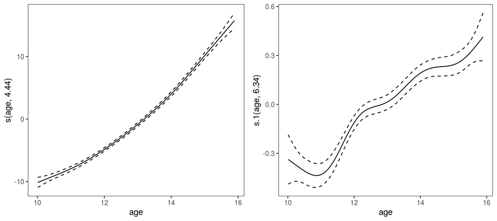

```r
print(plot(fit2), pages = 1)
```

We looks at a residual QQ-plot

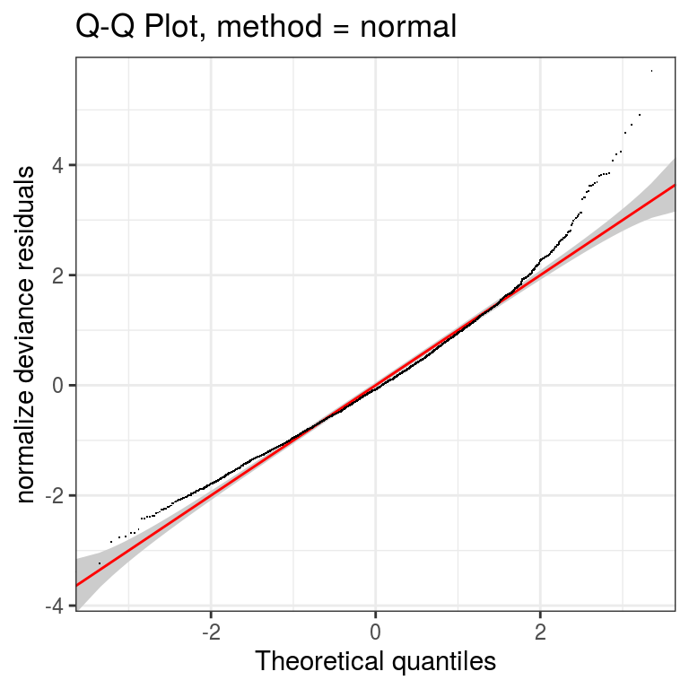

```r
qq(fit2, CI = "normal")
```

The residuals look skewed to the right. We can also know check whether the residual skewness (asymmetry) changes with age

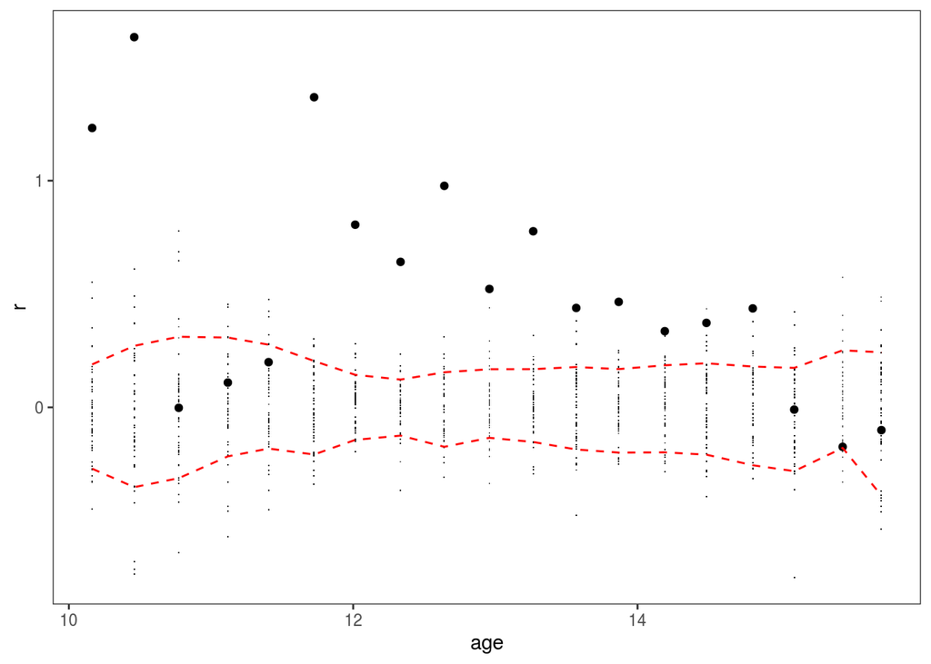

```r
library(e1071)
check1D(fit2, "age") + l_gridCheck1D( skewness )
```

It seems that the skewness decreases with age. It would have been difficult to see this directly from the data

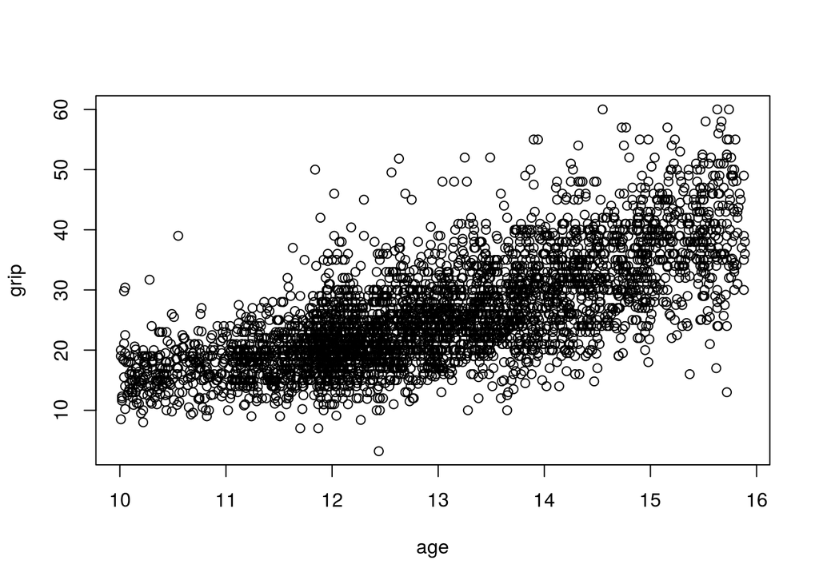

```r
plot(grip ~ age, data = grip)
```

We allow for skewness by adopting a `shash` model

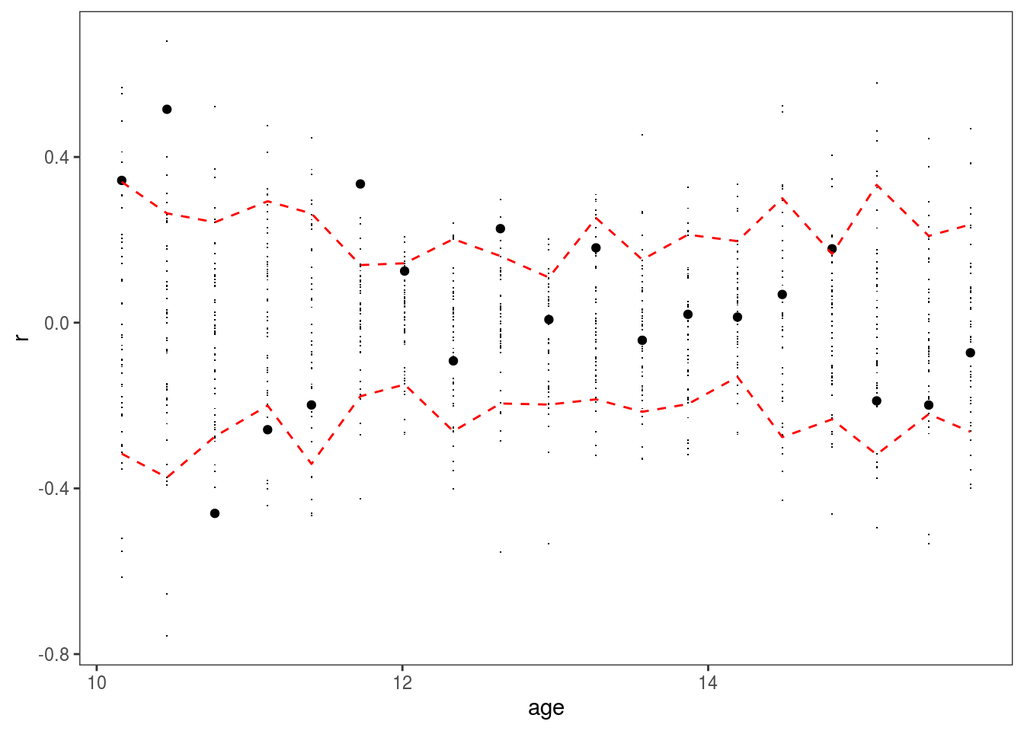

```r
library(mgcFam)
fit3 <- gamV(list(grip ~ s(age), # location
                  ~ s(age),      # scale (variance)
                  ~ s(age),      # skewness (asymmetry)
                  ~ 1),          # kurtosis (tail behaviour)
             data = grip,
             family = shash,
             aViz = list(nsim = 50))

check1D(fit3, "age") + l_gridCheck1D( skewness )
```

The skewness seems to be better modelled now, and we achieve lower AIC:

```r
AIC(fit1, fit2, fit3)
```

```
##             df      AIC
## fit1  6.603372 24369.57
## fit2 13.896755 24049.30
## fit3 15.239498 23873.99
```

The next step is to have a look at residual kurtosis (tail behaviour), this could be done by:

```r
check1D(fit3, "age") + l_gridCheck1D( kurtosis )
```

but we leave it for next time.

# More complex checks

An alternative conditional residual check is provided by `l_densCheck` layer. This compares the empirical and the theoretical (model based) residuals distribution. It generates a heat-map of:
$$\delta(x, r) = \verb|dFun|\{\hat{p}(r|x) - \phi(r|x) \},$$
where

- $\hat{p}(r|x)$ is an estimate of the conditional distribution of the residuals $r$;
- $\phi(r|x)$ is theoretical distribution (currently only $N(0, 1)$);
- `dFun` is a distance function. By default: `dFun <- function(emp, th) abs(sqrt(em)-sqrt(th))^(1/3)|.`

`l_densCheck` is useful for identifying residual anomalies, varying variance, skewness etc. Usage:

```r
check1D(fit1, "age") + l_densCheck(  )
```

Here are some examples on how to interpret such plots:

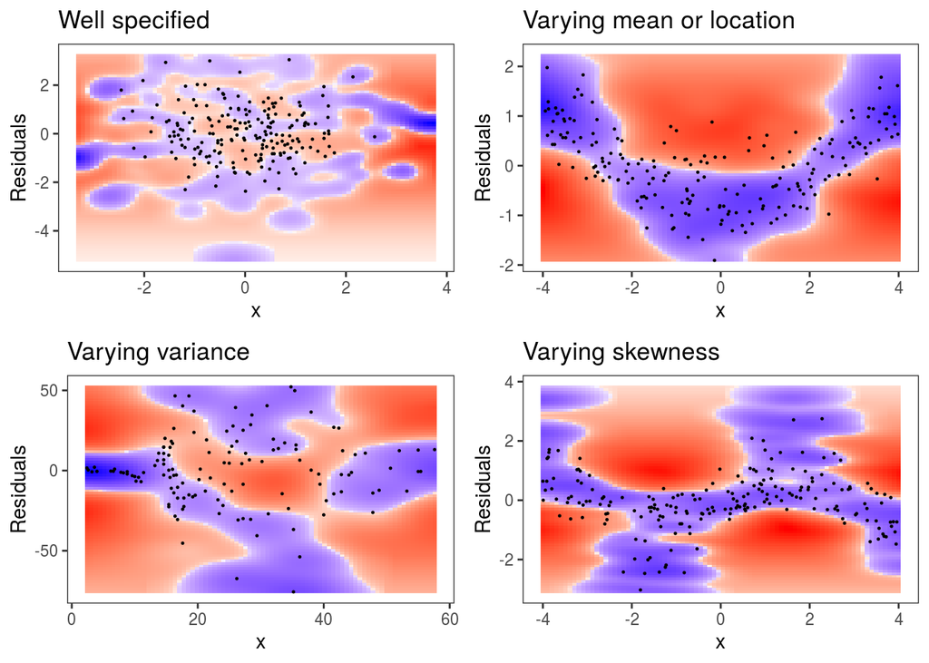